# tutorial

The scrollytellr app makes it easy to create scrolly telling webpages through a shiny graphical user interface

This tutorial will show you how to use the app to create a create scrolly telling webpage

To start, you can create stickies in the “Add stickies” tab

In particular, you give the sticky a name

Specify the type of sticky (text, image, or R code)

And add the sticky content, which in this example is the text of the Shelley poem Ozymandias

Next we can add narrations in the “Add Narration” tab

We select the sticky we want to add a narration to

We then add the narration text

We can also add narration options

For example, we can add the option to highlight a line of text

We can also set the appearance in the “Set Appearance” tab

We can view the quarto document in the “Quarto Document” tab

And we can view the full scrolly telling webpage output in the “HTML output” tab

When we view HTML output we can see the whole generated webpage

Finally we can use the “Downloads” menu, to download the Quarto Closeread document (in case we want to edit it further manually), and download the html webpage from this meu as well.

We hope you find the scrollytellr app useful!

We have already found it useful ourselves, as evidenced by the fact that we created this tutorial using the scrollytellr app :)

[figure not shown]

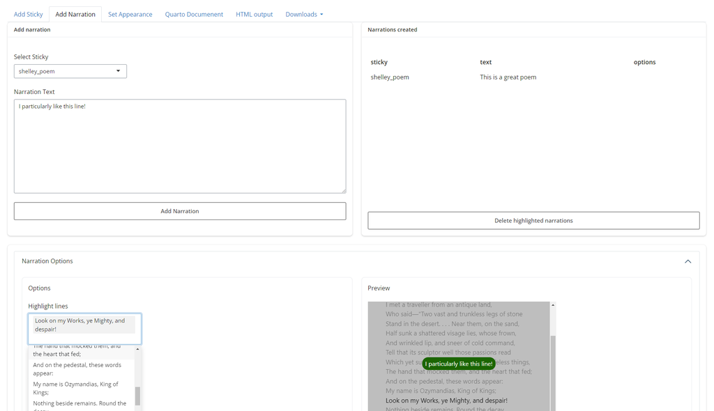

[figure not shown]